# Project: Prosper Loan Data

## Preliminary Wrangling

> Some important features that we will have to keep an eye on include:
> - **LoanOriginalAmount**: The origination amount of the loan.
> - **LoanOriginalDate**: The date the loan was originated.
> - **MonthlyLoanPayment**: The scheduled monthly loan payment
> - **LoanStatus**: The current status of the loan: Cancelled, Chargedoff, Completed, Current, Defaulted, FinalPaymentInProgress, PastDue.
> - **BorrowerAPR**: The Borrower's Annual Percentage Rate (APR) for the loan.
> - **BorrowerRate**: The Borrower's interest rate for this loan.
> - **Term**: The length of the loan expressed in months.
> - **EstimatedReturn**: The estimated return assigned to the listing at the time it was created.
> - **ProsperScore**: A custom risk score built using historical Prosper data. The score ranges from 1-10, with 10 being the best, or lowest risk score. Applicable for loans originated after July 2009.
> - **ListingCategory**: The category of the listing that the borrower selected when posting their listing.
> - **BorrowerState**: The two letter abbreviation of the state of the address of the borrower at the time the Listing was created.
> - **Occupation**: The Occupation selected by the Borrower at the time they created the listing.
> - **EmploymentStatus**:The employment status of the borrower at the time they posted the listing.
> - **DebtToIncomeRatio**: The debt to income ratio of the borrower at the time the credit profile was pulled.
> - **IncomeRange**: The income range of the borrower at the time the listing was created.
> - **StatedMonthlyIncome**: The monthly income the borrower stated at the time the listing was created.
> - **Recommendations**: Number of recommendations the borrower had at the time the listing was created.
> - **Investors**: The number of investors that funded the loan.

```python
# import all packages and set plots to be embedded inline
import numpy as np
import pandas as pd
import matplotlib.pyplot as plt
import seaborn as sb
import missingno as mno
%matplotlib inline
```

> Load in your dataset and describe its properties through the questions below. Try and motivate your exploration goals through this section.

```python
#Loading our dataset in a pandas dataframe

df=pd.read_csv('prosperLoanData.csv')
df.head()
```

|  | ListingKey | ListingNumber | ListingCreationDate | CreditGrade | Term | LoanStatus | ClosedDate | BorrowerAPR | BorrowerRate | LenderYield | ... | LP_ServiceFees | LP_CollectionFees | LP_GrossPrincipalLoss | LP_NetPrincipalLoss | LP_NonPrincipalRecoverypayments | PercentFunded | Recommendations | InvestmentFromFriendsCount | InvestmentFromFriendsAmount | Investors |
| --- | --- | --- | --- | --- | --- | --- | --- | --- | --- | --- | --- | --- | --- | --- | --- | --- | --- | --- | --- | --- | --- |
| 0 | 1021339766868145413AB3B | 193129 | 2007-08-26 19:09:29.263000000 | C | 36 | Completed | 2009-08-14 00:00:00 | 0.16516 | 0.1580 | 0.1380 | ... | -133.18 | 0.0 | 0.0 | 0.0 | 0.0 | 1.0 | 0 | 0 | 0.0 | 258 |
| 1 | 10273602499503308B223C1 | 1209647 | 2014-02-27 08:28:07.900000000 | NaN | 36 | Current | NaN | 0.12016 | 0.0920 | 0.0820 | ... | 0.00 | 0.0 | 0.0 | 0.0 | 0.0 | 1.0 | 0 | 0 | 0.0 | 1 |
| 2 | 0EE9337825851032864889A | 81716 | 2007-01-05 15:00:47.090000000 | HR | 36 | Completed | 2009-12-17 00:00:00 | 0.28269 | 0.2750 | 0.2400 | ... | -24.20 | 0.0 | 0.0 | 0.0 | 0.0 | 1.0 | 0 | 0 | 0.0 | 41 |
| 3 | 0EF5356002482715299901A | 658116 | 2012-10-22 11:02:35.010000000 | NaN | 36 | Current | NaN | 0.12528 | 0.0974 | 0.0874 | ... | -108.01 | 0.0 | 0.0 | 0.0 | 0.0 | 1.0 | 0 | 0 | 0.0 | 158 |
| 4 | 0F023589499656230C5E3E2 | 909464 | 2013-09-14 18:38:39.097000000 | NaN | 36 | Current | NaN | 0.24614 | 0.2085 | 0.1985 | ... | -60.27 | 0.0 | 0.0 | 0.0 | 0.0 | 1.0 | 0 | 0 | 0.0 | 20 |

5 rows × 81 columns

```python
# The shape/size of our data

df.shape
```

```
(113937, 81)
```

```python
#Checking additional information

df.info()
```

```
<class 'pandas.core.frame.DataFrame'>
RangeIndex: 113937 entries, 0 to 113936
Data columns (total 81 columns):
 #   Column                               Non-Null Count   Dtype
---  ------                               --------------   -----
 0   ListingKey                           113937 non-null  object
 1   ListingNumber                        113937 non-null  int64
 2   ListingCreationDate                  113937 non-null  object
 3   CreditGrade                          28953 non-null   object
 4   Term                                 113937 non-null  int64
 5   LoanStatus                           113937 non-null  object
 6   ClosedDate                           55089 non-null   object
 7   BorrowerAPR                          113912 non-null  float64
 8   BorrowerRate                         113937 non-null  float64
 9   LenderYield                          113937 non-null  float64
```

[output cut: 73 more lines]

```python
variables_of_interest=['LoanOriginalAmount','LoanStatus','ProsperScore','BorrowerAPR','BorrowerRate','EstimatedLoss',
                      'EstimatedReturn','BorrowerState','Occupation','EmploymentStatus','DebtToIncomeRatio',
                      'IncomeRange','MonthlyLoanPayment','StatedMonthlyIncome','ListingCategory (numeric)','Recommendations','Investors',
                      'LoanOriginationDate',]
df=df[variables_of_interest]
```

```python
df.head()
```

|  | LoanOriginalAmount | LoanStatus | ProsperScore | BorrowerAPR | BorrowerRate | EstimatedLoss | EstimatedReturn | BorrowerState | Occupation | EmploymentStatus | DebtToIncomeRatio | IncomeRange | MonthlyLoanPayment | StatedMonthlyIncome | ListingCategory (numeric) | Recommendations | Investors | LoanOriginationDate |
| --- | --- | --- | --- | --- | --- | --- | --- | --- | --- | --- | --- | --- | --- | --- | --- | --- | --- | --- |
| 0 | 9425 | Completed | NaN | 0.16516 | 0.1580 | NaN | NaN | CO | Other | Self-employed | 0.17 | $25,000-49,999 | 330.43 | 3083.333333 | 0 | 0 | 258 | 2007-09-12 00:00:00 |
| 1 | 10000 | Current | 7.0 | 0.12016 | 0.0920 | 0.0249 | 0.05470 | CO | Professional | Employed | 0.18 | $50,000-74,999 | 318.93 | 6125.000000 | 2 | 0 | 1 | 2014-03-03 00:00:00 |
| 2 | 3001 | Completed | NaN | 0.28269 | 0.2750 | NaN | NaN | GA | Other | Not available | 0.06 | Not displayed | 123.32 | 2083.333333 | 0 | 0 | 41 | 2007-01-17 00:00:00 |
| 3 | 10000 | Current | 9.0 | 0.12528 | 0.0974 | 0.0249 | 0.06000 | GA | Skilled Labor | Employed | 0.15 | $25,000-49,999 | 321.45 | 2875.000000 | 16 | 0 | 158 | 2012-11-01 00:00:00 |
| 4 | 15000 | Current | 4.0 | 0.24614 | 0.2085 | 0.0925 | 0.09066 | MN | Executive | Employed | 0.26 | $100,000+ | 563.97 | 9583.333333 | 2 | 0 | 20 | 2013-09-20 00:00:00 |

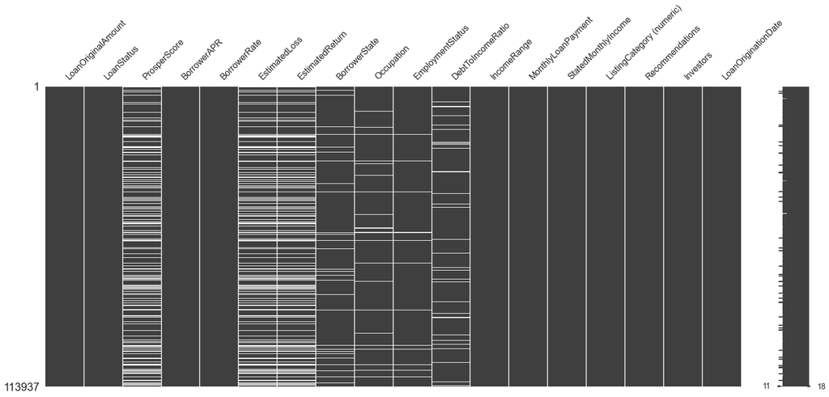

```python
#visualizing missing data

mno.matrix(df)
```

We notice that several features, alongside the `ProsperScore` feature have many missing values. By taking a look into the documentation sheet we realize that the Prosper Scores and Estimated Loss and Return variables are only available after July 2009.

In order to see clearly the pattern of the missing values we will visualize it again for the the period before July 2009.

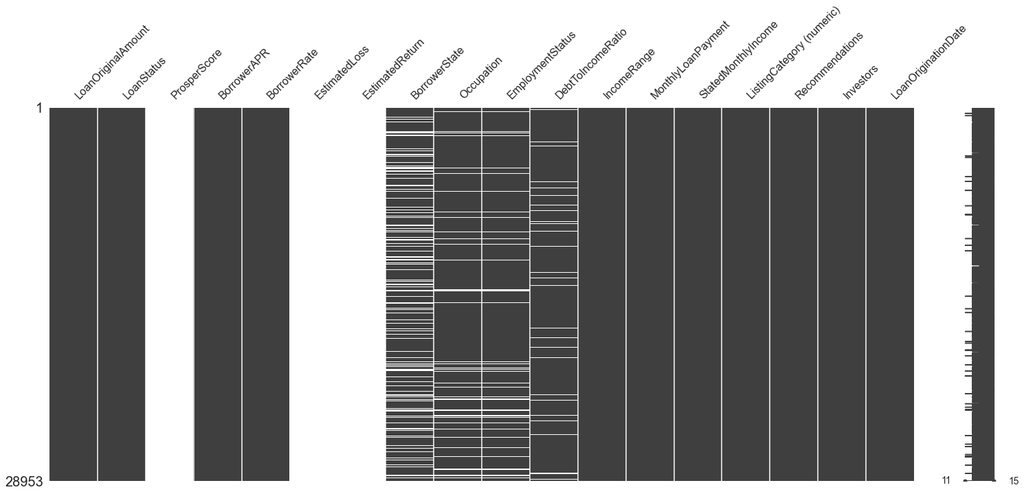

```python
mno.matrix(df.query('LoanOriginationDate<"2009-07"'))
```

Since variables like the ProperScore are important for our analysis and do not include information prior a specific date, we will fill them using the mean. We will do the same for BorrowerAPR and the DebtToIncomeRatio

```python
columns=['BorrowerAPR','EstimatedReturn','EstimatedLoss','ProsperScore','DebtToIncomeRatio']

for i in columns:
    df[i].fillna(df[i].mean(),inplace=True)
```

```python
#Testing

df[columns].isna().sum()
```

```
BorrowerAPR          0
EstimatedReturn      0
EstimatedLoss        0
ProsperScore         0
DebtToIncomeRatio    0
dtype: int64
```

- From the documentation table we are able to notice that the numbers in the `ListingCategory (numeric)` column correspond to a specific category. We will map these number to their respective categories.
- We will also turn the `LoanOriginationDate` into a Datetime object, after we remove the hour part.

```python
df.rename({'ListingCategory (numeric)':'ListingCategory'},axis=1,inplace=True)

mapper={0 :'Not Available', 1:'Debt Consolidation', 2:'Home Improvement', 3:'Business', 4:'Personal Loan',
        5:'Student Use', 6:'Auto', 7:'Other', 8:'Baby&Adoption', 9:'Boat', 10:'Cosmetic Procedure',
        11:'Engagement Ring', 12:'Green Loans', 13:'Household Expenses', 14:'Large Purchases',
        15:'Medical/Dental', 16:'Motorcycle', 17:'RV', 18:'Taxes', 19:'Vacation', 20:'Wedding Loans'}

df.ListingCategory.replace(mapper,inplace=True)
```

```python
df.LoanOriginationDate=df.LoanOriginationDate.str[0:10]
df.LoanOriginationDate=pd.to_datetime(df.LoanOriginationDate)
```

```python
#Testing

df.head()
```

|  | LoanOriginalAmount | LoanStatus | ProsperScore | BorrowerAPR | BorrowerRate | EstimatedLoss | EstimatedReturn | BorrowerState | Occupation | EmploymentStatus | DebtToIncomeRatio | IncomeRange | MonthlyLoanPayment | StatedMonthlyIncome | ListingCategory | Recommendations | Investors | LoanOriginationDate |
| --- | --- | --- | --- | --- | --- | --- | --- | --- | --- | --- | --- | --- | --- | --- | --- | --- | --- | --- |
| 0 | 9425 | Completed | 5.950067 | 0.16516 | 0.1580 | 0.080306 | 0.096068 | CO | Other | Self-employed | 0.17 | $25,000-49,999 | 330.43 | 3083.333333 | Not Available | 0 | 258 | 2007-09-12 |
| 1 | 10000 | Current | 7.000000 | 0.12016 | 0.0920 | 0.024900 | 0.054700 | CO | Professional | Employed | 0.18 | $50,000-74,999 | 318.93 | 6125.000000 | Home Improvement | 0 | 1 | 2014-03-03 |
| 2 | 3001 | Completed | 5.950067 | 0.28269 | 0.2750 | 0.080306 | 0.096068 | GA | Other | Not available | 0.06 | Not displayed | 123.32 | 2083.333333 | Not Available | 0 | 41 | 2007-01-17 |
| 3 | 10000 | Current | 9.000000 | 0.12528 | 0.0974 | 0.024900 | 0.060000 | GA | Skilled Labor | Employed | 0.15 | $25,000-49,999 | 321.45 | 2875.000000 | Motorcycle | 0 | 158 | 2012-11-01 |
| 4 | 15000 | Current | 4.000000 | 0.24614 | 0.2085 | 0.092500 | 0.090660 | MN | Executive | Employed | 0.26 | $100,000+ | 563.97 | 9583.333333 | Home Improvement | 0 | 20 | 2013-09-20 |

```python
df.info()
```

```
<class 'pandas.core.frame.DataFrame'>
RangeIndex: 113937 entries, 0 to 113936
Data columns (total 18 columns):
 #   Column               Non-Null Count   Dtype
---  ------               --------------   -----
 0   LoanOriginalAmount   113937 non-null  int64
 1   LoanStatus           113937 non-null  object
 2   ProsperScore         113937 non-null  float64
 3   BorrowerAPR          113937 non-null  float64
 4   BorrowerRate         113937 non-null  float64
 5   EstimatedLoss        113937 non-null  float64
 6   EstimatedReturn      113937 non-null  float64
 7   BorrowerState        108422 non-null  object
 8   Occupation           110349 non-null  object
 9   EmploymentStatus     111682 non-null  object
 10  DebtToIncomeRatio    113937 non-null  float64
 11  IncomeRange          113937 non-null  object
 12  MonthlyLoanPayment   113937 non-null  float64
 13  StatedMonthlyIncome  113937 non-null  float64
 14  ListingCategory      113937 non-null  object
 15  Recommendations      113937 non-null  int64
 16  Investors            113937 non-null  int64
 17  LoanOriginationDate  113937 non-null  datetime64[ns]
dtypes: datetime64[ns](1), float64(8), int64(3), object(6)
memory usage: 15.6+ MB
```

```python
#We will now replace the 'Not available' and 'Not displayed' Categorical data with np.nan
#Then we will drop the rows with nan observations to not interfere with our analysis

df.replace('Not displayed',np.nan,inplace=True)
df.replace('Not available',np.nan,inplace=True)
df.replace('Not Available',np.nan,inplace=True)


df.dropna(inplace=True)
```

```python
#Checking Prosper Scores for mistakes

df.ProsperScore.value_counts()
```

```
4.000000     12255
6.000000     12123
5.950067     12098
8.000000     11942
7.000000     10444
5.000000      9680
3.000000      7433
9.000000      6875
2.000000      5617
10.000000     4711
11.000000     1436
1.000000       984
Name: ProsperScore, dtype: int64
```

```python
#Fixing incosistency with ProsperScore values, turning them into integers
df.ProsperScore=df.ProsperScore.astype(int)
```

```python
df.ProsperScore.value_counts()
```

```
5     21778
4     12255
6     12123
8     11942
7     10444
3      7433
9      6875
2      5617
10     4711
11     1436
1       984
Name: ProsperScore, dtype: int64
```

```python
#checking
df.shape
```

```
(95598, 18)
```

```python
df.info()
```

```
<class 'pandas.core.frame.DataFrame'>
Int64Index: 95598 entries, 1 to 113936
Data columns (total 18 columns):
 #   Column               Non-Null Count  Dtype
---  ------               --------------  -----
 0   LoanOriginalAmount   95598 non-null  int64
 1   LoanStatus           95598 non-null  object
 2   ProsperScore         95598 non-null  int32
 3   BorrowerAPR          95598 non-null  float64
 4   BorrowerRate         95598 non-null  float64
 5   EstimatedLoss        95598 non-null  float64
 6   EstimatedReturn      95598 non-null  float64
 7   BorrowerState        95598 non-null  object
 8   Occupation           95598 non-null  object
 9   EmploymentStatus     95598 non-null  object
 10  DebtToIncomeRatio    95598 non-null  float64
 11  IncomeRange          95598 non-null  object
 12  MonthlyLoanPayment   95598 non-null  float64
 13  StatedMonthlyIncome  95598 non-null  float64
 14  ListingCategory      95598 non-null  object
 15  Recommendations      95598 non-null  int64
 16  Investors            95598 non-null  int64
 17  LoanOriginationDate  95598 non-null  datetime64[ns]
dtypes: datetime64[ns](1), float64(7), int32(1), int64(3), object(6)
memory usage: 13.5+ MB
```

```python
df.describe()
```

|  | LoanOriginalAmount | ProsperScore | BorrowerAPR | BorrowerRate | EstimatedLoss | EstimatedReturn | DebtToIncomeRatio | MonthlyLoanPayment | StatedMonthlyIncome | Recommendations | Investors |
| --- | --- | --- | --- | --- | --- | --- | --- | --- | --- | --- | --- |
| count | 95598.000000 | 95598.000000 | 95598.000000 | 95598.000000 | 95598.000000 | 95598.000000 | 95598.000000 | 95598.000000 | 9.559800e+04 | 95598.000000 | 95598.000000 |
| mean | 8714.986433 | 5.843114 | 0.223845 | 0.194924 | 0.080337 | 0.096269 | 0.259398 | 282.042996 | 5.798713e+03 | 0.037846 | 77.493243 |
| std | 6278.616828 | 2.243522 | 0.081664 | 0.076226 | 0.043807 | 0.028533 | 0.314002 | 189.702466 | 7.878364e+03 | 0.295987 | 102.996817 |
| min | 1000.000000 | 1.000000 | 0.013150 | 0.000000 | 0.004900 | -0.182700 | 0.000000 | 0.000000 | 0.000000e+00 | 0.000000 | 1.000000 |
| 25% | 4000.000000 | 4.000000 | 0.158500 | 0.134900 | 0.047400 | 0.077130 | 0.160000 | 144.510000 | 3.333333e+03 | 0.000000 | 1.000000 |
| 50% | 7000.000000 | 5.000000 | 0.214340 | 0.184500 | 0.080306 | 0.096068 | 0.240000 | 236.750000 | 4.916667e+03 | 0.000000 | 40.000000 |
| 75% | 13000.000000 | 8.000000 | 0.289740 | 0.256600 | 0.105000 | 0.113480 | 0.310000 | 380.510000 | 7.083333e+03 | 0.000000 | 111.000000 |
| max | 35000.000000 | 11.000000 | 0.423950 | 0.360000 | 0.366000 | 0.283700 | 10.010000 | 2251.510000 | 1.750003e+06 | 39.000000 | 1189.000000 |

### What is/are the main feature(s) of interest in your dataset?

> The main features that we are interested in exploring more are the ProsperScore, LoanStatus the BorrowerAPR and the LoanOriginalAmount. Specifically, we will attempt to find out what factor/s affect the values of these variables

### What features in the dataset do you think will help support your investigation into your feature(s) of interest?

> According to traditional finance we should expect that the interest rate, `BorrowerAPR` to increase as the size of loan increases, to accommodate the increased risk associated with the loan. It is also expected that the DebtToIncomeRatio, the Occupation and the Recommendations may have somethind to do with the LoanStatus and the ProsperScore. The Listing Categories could be influencing the LoanOriginalAmount and the Investor may be more when the EstimatedReturn is higher.

## Univariate Exploration

> We will begin our analysis by checking the distributions and the value counts of individual variables

## LoanOriginalAmount - BorrowerAPR - ProsperScore - Distributions

We will check the distribution of the Loan amounts, Borrower APM and Prosper Score to get an overview of these features.

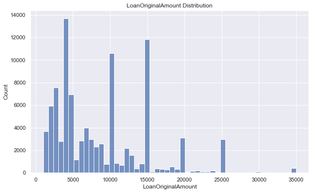

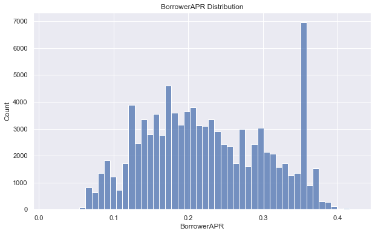

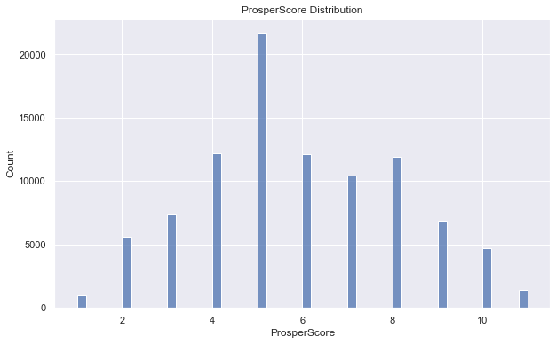

```python
sb.set(rc={'figure.figsize':(10,6)})

columns=['LoanOriginalAmount','BorrowerAPR','ProsperScore']
for i in columns:
    sb.histplot(df,x=i,bins=50)
    plt.title(i+' Distribution')
    plt.show();
```

We can see that the Loan Amounts form a right-skewed distribution which means that the majority of the loans were relatively small amounts. Some outliers however exist at the amounts of 10000, 15000, 20000, 25000 and 35000.

Borrower's APR distribution seems to be multi-modal with several peaks at about 0.1, 0.17, 0.21, 0.3 and 0.36. Specifically 0.36 accounts for the APR of over 7000 loans which makes it by far the most popular Borrower's APR

Finally, the ProsperScore forms an almost perfect normal distribution with a mean of 6.

# MonthlyLoanPayment - StatedMonthlyIncome - DebtToIncomeRatio

We will proceed by examining these three features to get insights about their values

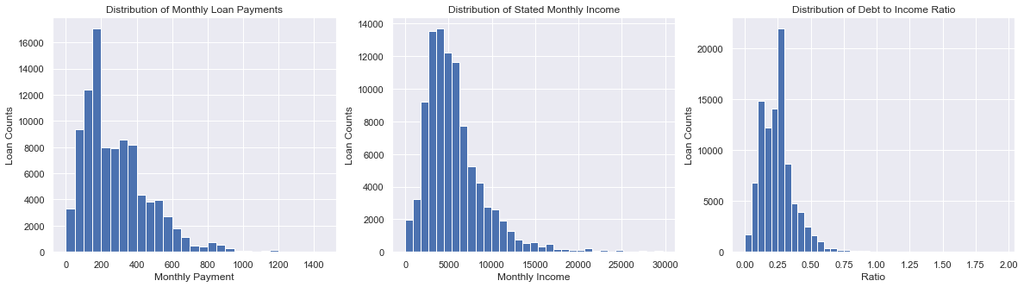

```python
fig,ax = plt.subplots(1,3,figsize=(20,5))

ax[0].hist(data=df,x='MonthlyLoanPayment',bins=np.arange(0,1500,50))
ax[0].set_title('Distribution of Monthly Loan Payments')
ax[0].set_xlabel('Monthly Payment')
ax[0].set_ylabel('Loan Counts')

ax[1].hist(data=df,x='StatedMonthlyIncome',bins=np.arange(0,30000,900))
ax[1].set_title('Distribution of Stated Monthly Income')
ax[1].set_ylabel('Loan Counts')
ax[1].set_xlabel('Monthly Income')

ax[2].hist(data=df,x='DebtToIncomeRatio',bins=np.arange(0,2,0.05))
ax[2].set_title('Distribution of Debt to Income Ratio')
ax[2].set_xlabel('Ratio')
ax[2].set_ylabel('Loan Counts');
```

```python
print(df.MonthlyLoanPayment.mean() , df.StatedMonthlyIncome.mean())
print(df.MonthlyLoanPayment.median(),df.StatedMonthlyIncome.median())
print(df.DebtToIncomeRatio.mean(),df.DebtToIncomeRatio.median())
```

```
282.04299587857486 5798.713352617973
236.75 4916.666667
0.2593981329228661 0.24
```

All three distributions above are right-skewed. It is evident that the majority of the loans were given to people with a monthly income between 2000-9000. Most Monthly payments are arouns 200 dollars and the Debt to Income Ration close to 0.25. The extreme Income outliers will be removed below:

```python
df=df[df.StatedMonthlyIncome<30000]
df.reset_index(inplace=True)
```

# Loan Status

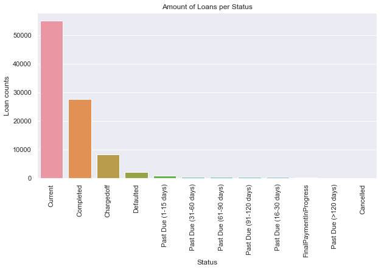

```python
plt.figure(figsize=(10,5))
sb.barplot(y=df.LoanStatus.value_counts(),x=df.LoanStatus.value_counts().index);
plt.xticks(rotation=90)
plt.title('Amount of Loans per Status')
plt.ylabel('Loan counts')
plt.xlabel('Status');
```

# Listing Categories

We will now check which categories are the most common ones among the loans

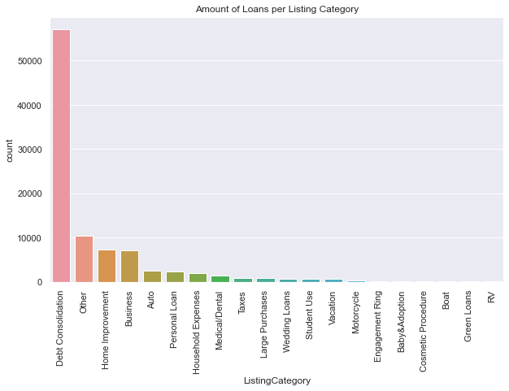

```python
 # Listing Category

plt.figure(figsize=(10,6))
sb.countplot(data=df,x='ListingCategory',order=df.ListingCategory.value_counts().index)
plt.xticks(rotation=90);
plt.title('Amount of Loans per Listing Category');
```

It is made clear that most loans are for Debt Consolidation, with the 'Other' category following up before the Home improvements and the Business. We will now proceed by checking the EmploymentStatus and the IncomeRanges.

# EmploymentStatus - IncomeRange

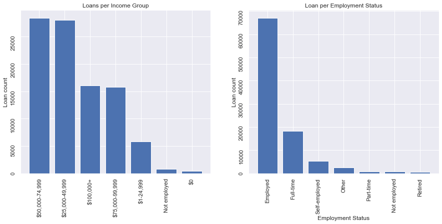

```python
fig,ax= plt.subplots(1,2,figsize=(15,6))

ax[0].bar(x=df.IncomeRange.value_counts().index,height=df.IncomeRange.value_counts())
ax[0].set_title('Loans per Income Group')
ax[0].set_ylabel("Loan count")
ax[0].tick_params(rotation=90)

ax[1].bar(x=df.EmploymentStatus.value_counts().index,height=df.EmploymentStatus.value_counts());
ax[1].tick_params(rotation=90);
ax[1].set_title('Loan per Employment Status');
ax[1].set_xlabel("Employment Status")
ax[1].set_ylabel("Loan count");
```

Our observations in this step include that the majority of the loans were given to Income groups (yearly) 25.000-49.000 and 50.000-74.999. While the overwhelming majority of those who took a loan were Employed.

## Bivariate Exploration

> First, we will take a look at the pairwise correlations present in our data

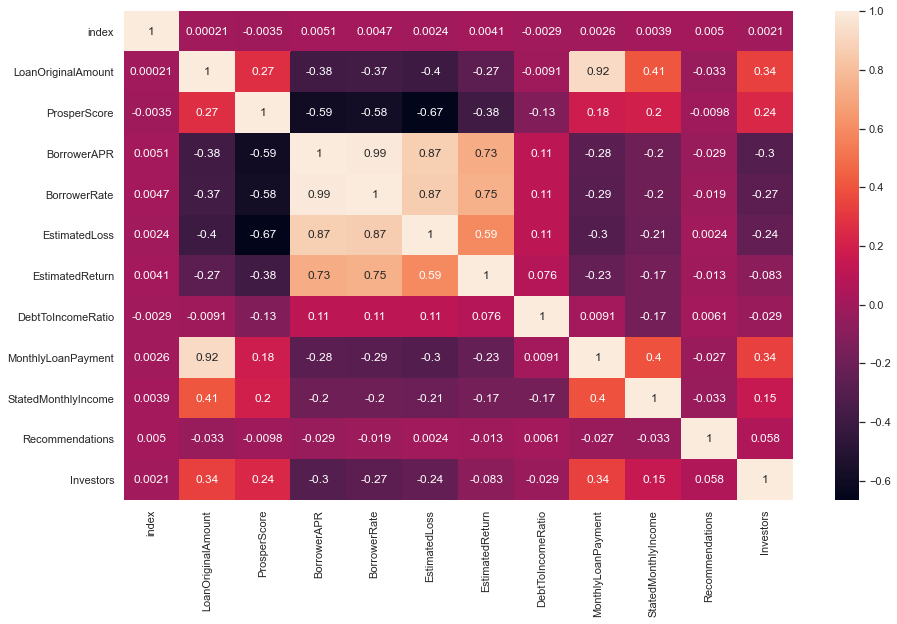

```python
plt.figure(figsize=(15,9))
sb.heatmap(df.corr(),annot=True);
```

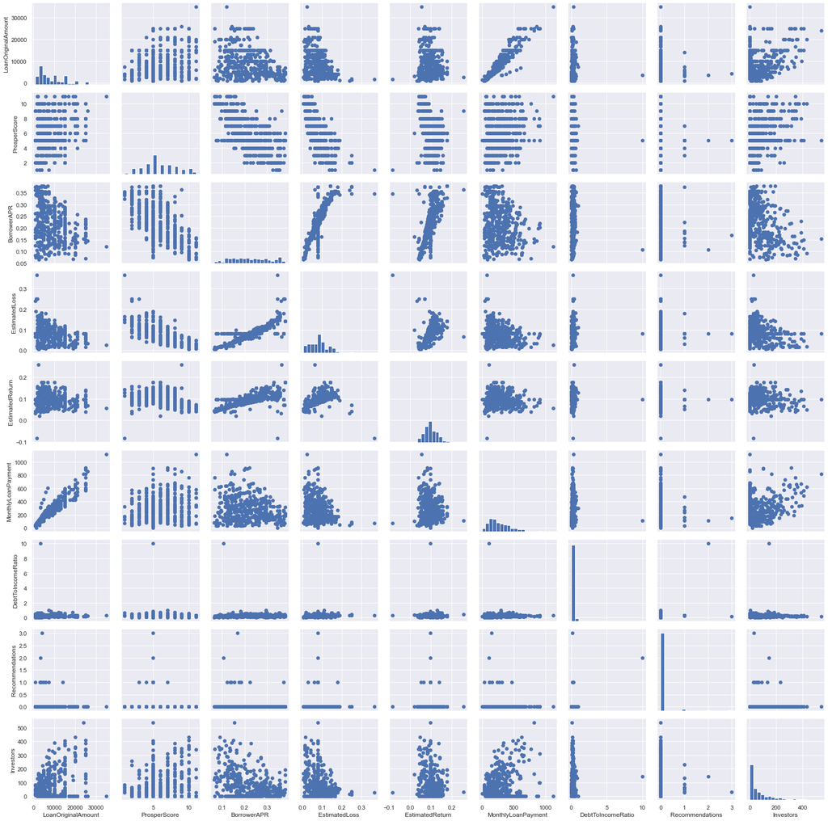

```python
numeric_vars=["LoanOriginalAmount","ProsperScore","BorrowerAPR","EstimatedLoss","EstimatedReturn",
              "MonthlyLoanPayment","DebtToIncomeRatio","Recommendations","Investors"]

plt.figure(figsize=(10,6))
samples=np.random.choice(df.shape[0],500,replace=False)
df_sampl=df.loc[samples,:]

g=sb.PairGrid(data=df_sampl,vars=numeric_vars)
g=g.map_diag(plt.hist,bins=20)
g.map_offdiag(plt.scatter);
```

### Observations:

We notice some interesting correlations here, some of which were expected and some were not.

We will now proceed by taking a look into the relations between Categorical and Numerical Variables

## Loan Amount - Listing Categories, Employment Status and Loan Status

We will check through violinplots how the total Loan amount is related to specific categorical variables

```python
def violinplots(df,cols,y):
    fig, axes = plt.subplots(nrows=4, ncols=1, figsize=(10, 30))
    for name, ax in zip(cols, axes):
        sb.violinplot(data=df, x=name, y=y, ax=ax)
        ax.set_title(name)
        ax.set_ylabel(y)
        ax.tick_params(rotation=90)
    plt.subplots_adjust(hspace=0.6)
```

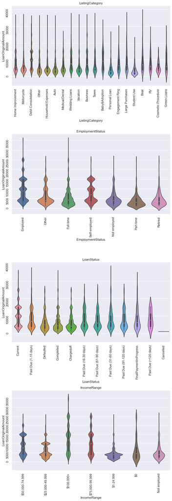

```python
violinplots(df,['ListingCategory','EmploymentStatus','LoanStatus','IncomeRange'],'LoanOriginalAmount')
```

In all the violin plots, we are able to spot that the big bulk of the Loan Amounts goes up to 15000. However, larger amounts seem to be given for Debt Consolidation. In addtion, people with Employed and Full-Time status are also more likely to receive higher amount loans.

The LoanStatus do not seem particularly related to the Loan Amount, although the 'Current' status includes more Loans of higher amounts. Finally, the higher income groups seem to also be getting higher loan amounts which is a rather reasonable observation.

Now we will compare the BorrowerAPR variable.

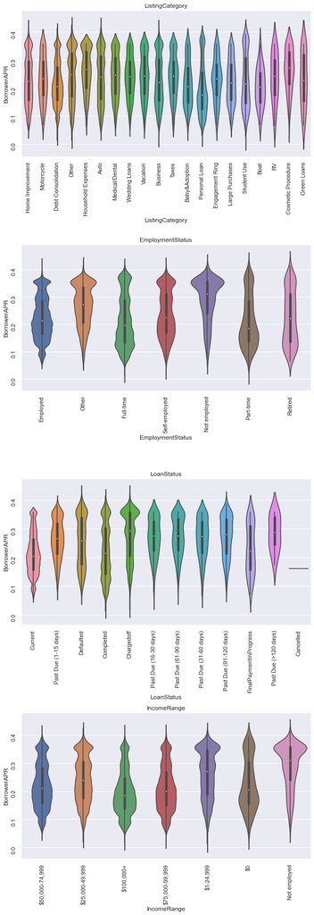

```python
violinplots(df,['ListingCategory','EmploymentStatus','LoanStatus','IncomeRange'],'BorrowerAPR')
```

## Observations

The BorrwerAPR does not seem particularly related to the Listing Categories as they all cover a wide range of APRs.

- Unemployed people receiver get a higher BorrowerAPR which is probably reasonable as they entail higher risk.
- Interestingly enough part-time status is more likely to receive a lower APR than a higher one.
- Retired people are as much likely to get a high APR as a low APR.
- Different income group can still get a wide variety of different APR'S, although it is to be noted that 0$ income group are more likely to have a Lower APR. Overall, the correlation between IncomeRange groups and BorrwerAPR seems weak.

## Checking relation between APR, State and ProsperScore

```python
def boxplots(df,cols):
    fig, axes = plt.subplots(nrows=2, ncols=1, figsize=(15, 12))
    for name, ax in zip(cols, axes):
        sb.boxplot(data=df, x=name, y='BorrowerAPR', ax=ax)
        ax.set_title(name)
        ax.set_ylabel('APR')
        if name=='ListingCategory' or name=="LoanStatus":
            ax.tick_params(rotation=90)
    plt.subplots_adjust(hspace=0.4)
```

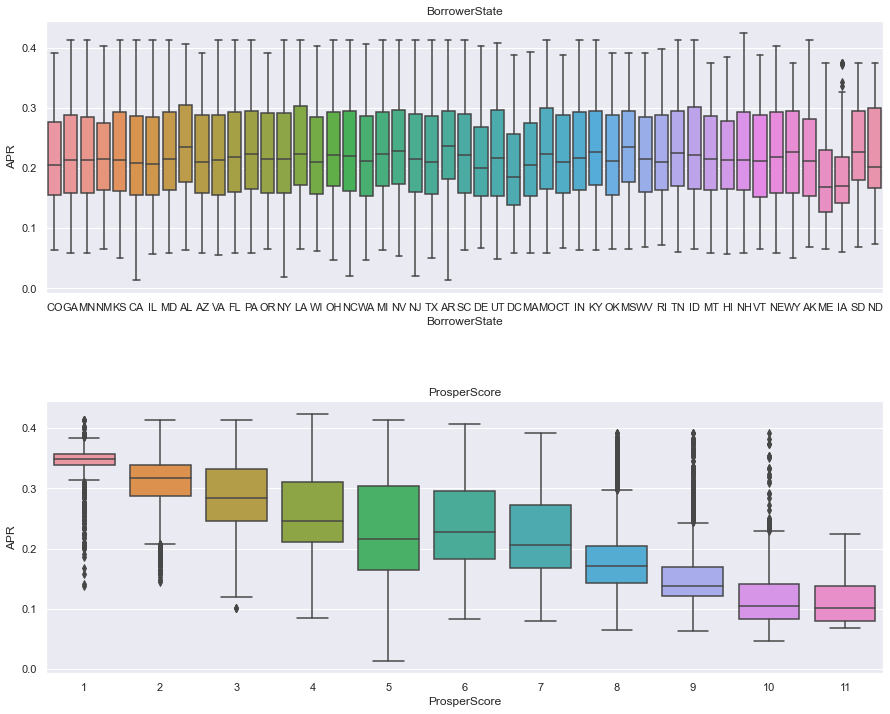

```python
boxplots(df,['BorrowerState','ProsperScore'])
```

Generally, the APR does not look particularly affected by the State of origin of the borrower. However, the states of Maine and Iowa seem to be getting a lower APR overall.

The interesting but expected observation here is that loans with higher ProsperScore are getting a visibly lower APR, while loans with lower score a significantly higher APR. That's reasonable considering that the ProsperScore is also a reflection of the risk that each loan entails.

## Checking how ProsperScore is related to Income Range and Loan Status

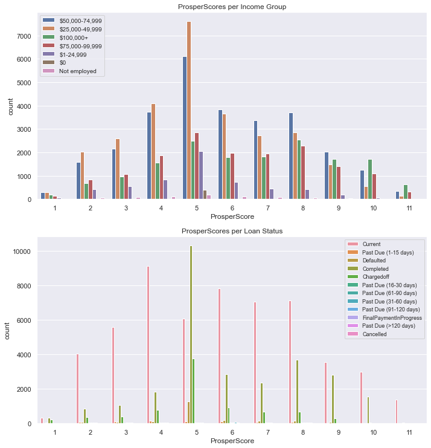

```python
plt.figure(figsize=(10,10))

plt.subplot(2,1,1)
sb.countplot(data=df,x='ProsperScore',hue='IncomeRange');
plt.legend(loc=2, prop={'size': 10})
plt.title('ProsperScores per Income Group')
plt.tight_layout()
plt.subplots_adjust(hspace=0.2)

ax=plt.subplot(2,1,2)
sb.countplot(data=df,x='ProsperScore',hue='LoanStatus')
plt.legend(loc=1, prop={'size': 9})
plt.title('ProsperScores per Loan Status');
```

Obersvations:

- The higher we move to ProsperScores, the more likely it becomes to encounter higher income groups and vice versa.
- The higher we move to ProsperScores, the less likely it becomes to encounter Past Due, Defaulted or Chargedoff loans.

The ProsperScores seem to be a good reflection of the risk that some loans entail.

### Did you observe any interesting relationships between the other features (not the main feature(s) of interest)?

> One rather interesting observation was that the State of origin of the borrower as well as the Listing Categories were not playing any significant role in determining the APR. Although it was observed that Maine and Iowa tend to get lower APRs in comparison to the rest.

## Multivariate Exploration

> We will now explore some of the univariate and bivariate observations and relations that we found above, in multivariate visuals.

### Prosper Score in relation to Borrower APR and Loan Amount

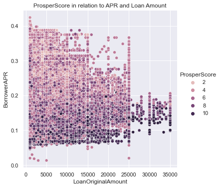

```python
sb.relplot(data=df,x='LoanOriginalAmount',y='BorrowerAPR',hue='ProsperScore');
plt.title('ProsperScore in relation to APR and Loan Amount');
```

We can see here again, that lower APR translates to higher Proper Score. In addition, we can see observe the negative relation between APR and Loan Amount. Higher Loan amounts equal to a lower APR and overall a higher Prosper Score.

### Income Ranges in relation to APR and Loan amounts

Now we will explore in the same manner how the different income groups relate to APR and loan sizes.

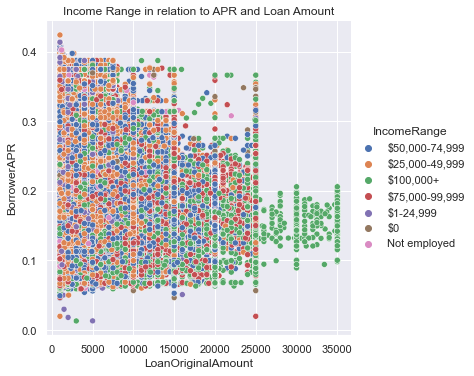

```python
sb.relplot(data=df,x='LoanOriginalAmount',y='BorrowerAPR',hue='IncomeRange');
plt.title('Income Range in relation to APR and Loan Amount');
```

We can verify here the positive relation between higher loans and higher income ranges, which again makes sense.

### ProsperScore in relation to EstimatedLoss and APR

Finally we will check the positive relation that we found between APR and EstimatedLoss, and both of them will be compared to ProsperScores

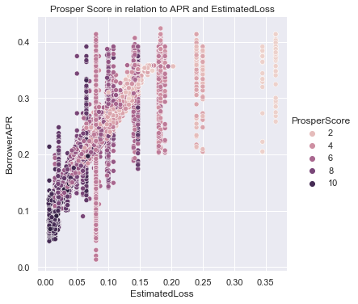

```python
sb.relplot(data=df,x='EstimatedLoss',y='BorrowerAPR',hue='ProsperScore');
plt.title('Prosper Score in relation to APR and EstimatedLoss');
```

It is evident that the lower the EstimatedScore, the lower the APR is. Simultaneously, lower Estimated Scores and APRs translate to a higher Prosper Score. So we can conclude that these are rather good factors in determining the Prosper Score.

### LoanStatus and Prosper Score in relation to Estimated Loss

As a final insight, we will check the relation between Estimated Loss, Proper Score and the status of the loans.

As we can see below, the loans wish small Estimated loss featured a higher Prosper Score as we saw earlier. But in addition to that, we are now able to see that the loans with the status of `Defaulted`, `Completed` and `Changed off` also featured a higher Estimated Loss and consequently a lower Prosper Score than the rest.

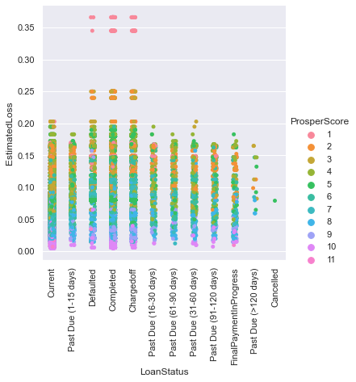

```python
sb.catplot(x="LoanStatus", y="EstimatedLoss", hue="ProsperScore", data=df)
plt.xticks(rotation=90);
```

### Talk about some of the relationships you observed in this part of the investigation. Were there features that strengthened each other in terms of looking at your feature(s) of interest?

> We verified a lot of the relationships that we found earlier in a more complete manner. We realized that lower APR means higher ProsperScore while Large Loan Amounts also bear a higher ProsperScore and come from people with high incomes. In addition, we spotted a positive relation between the Estimated Loss and the APR and consequently a negative one with the Prosper Scores. Finally, it was made clear that the Defaulted, Changed off and Completed Loans had a higher Estimated Loss and feature lower Prosper Score.

### Were there any interesting or surprising interactions between features?

> The results were very intuitive in the sense that they mostly make sense from a financial point of view. Loans with higher Estimated Loss, entail more risk, therefore they have a higher APR and a lower overall ratin and vice versa. Also, people with higher incomes are naturally more in position to take larger loans and have better chances in getting a lower APR and a higher Score.